# Introducing stylometry

Last revision: 2020-05-13

# Differences & similarties

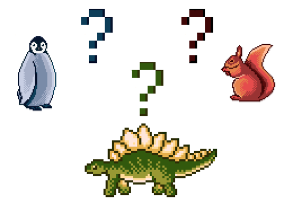

The word “style“ has wide everyday usage and tangled, rich tradition of scholarly writing on it in several disciplines (from fashion to architecture to language). We speak about “style“ of our clothes, “style“ of a drawning, “style“ of a writer, composer or director or even “style“ of cultural epochs (Roman, Baroque, Classical, etc.). In other words, “style“ can express variety of specific manners of doing variety of things: dressing, playing games, living your life, doing lecture notes.

A “style“ could be everywhere where a difference, a variation is. It’s useful, for now, to shift the emphasis from (artistic) “style“ to a general notion of “difference“. There are many ways to speak about a variation, many ways to measure or formalize differences in things. Take, for example, a group of animals: a stegosaur, a penguin and a squirrel.

## A dinosaur, a bird and a rodent walk into the bar

How similar and how different are these creatures? One way to argue about differences in animals is to look at the evolutionary path each species has undergone. Thanks to morphological, paleontological and genetic data, we know that stegosaurs and penguins are “closer“ to each other than to squirrels. We can represent their relationships on a tree, like that

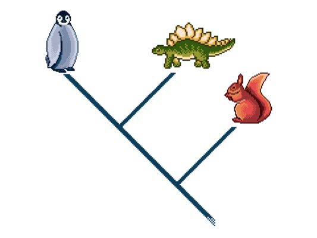

Now, (an old-fashioned) tree in evolutionary biology serves as a model of history, a model of change: over time species branch to several other species, who, in turn, could branch more. So our tree above implies a “distance“ between animals of some sort: a distance of common heritage. Penguins and stegosaurs are closer to each other because a “common ancestor“ of these two was living more recently, than common ancestors of all three guys (which would need to be an ancestor of both mammals & reptilians).

While keeping the general idea of a “distance“ (we can say it is a “magnitude“ of differences between things) in mind, let’s replace animals on the tips of our tree with something different: textual traditions (some would have an urge to call them “genres“). Realistic fiction, detective novel, religious writing.

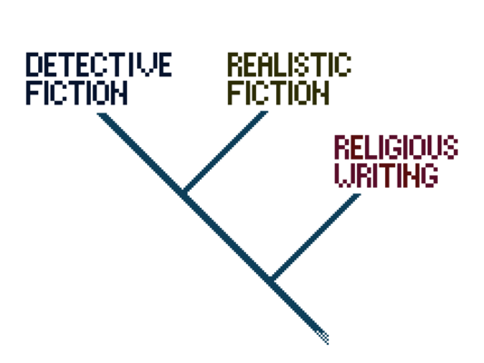

Now, we don’t have an abundant paleontological data to support a new tree and we rather not engage in critical discussion on genre existence. However, intuition tells me that realistic & detective novel are closer to each other than both of them to religious writing. For one thing, both of fiction genres are products of 19th century Western literary tradition, while religious texts are definitly older than that and are not localized in the West (disregard the ancestrial relationships which are implied by the tree for now, but a morphological meditation on “ancestors“ of writing traditions may be extremely interesting).

You may object that we are comparing apples to oranges here (modern fiction to non-fiction of radically different function). However, in stylometry terms it is more productive to think that there is a distances between apples and oranges too. Instead of discrete boxes of impenetrable boundaries (say, genres) imagine a continious space of “difference“ of some sort.

Let’s change our tree tips once more and take only “apples“ this time: three detective texts written by two authors.

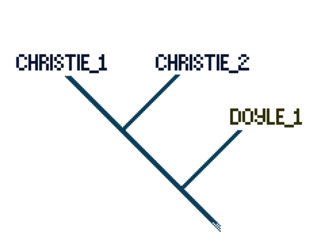

We usually assume (and hope) that two texts of Agatha Christie would share more similarities - expressed in whatever terms you like - with each other, than each of them to some text of Arthur Conan Doyle. This is also a fundamental assumption of the field of authorship attribution: two texts of one author would be closer to each other than to any other text out there.

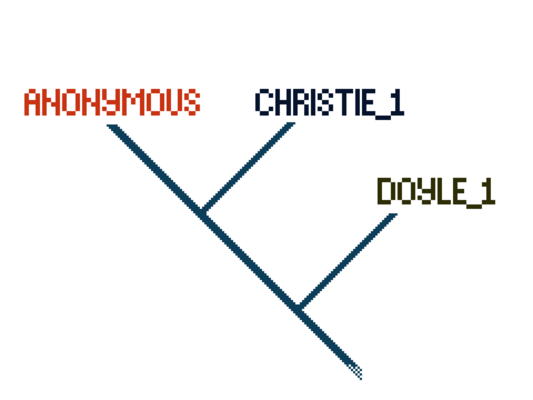

The problem, however, is that there is no defined or singular “scale of difference“ for texts. “Similarity“ for one group of literary scholars using one group of features and arguments could consitute a “difference“ for the other. Stylometry emerged as a field of study in 19th century to solve applied problems (authorship and question of chronology) relying on a quantifyable way to approach differences in texts.

## Excuse me, how far is it to author X?

It is time to get rid of the tree: we don’t really know which features constitute and support it’s structure. We will now set on two quite quantifyiable features of texts and move to a two-dimensional plane. These two features are frequencies of words “the“ and “is“ - two of the most frequent words in English. If we count words in the texts it will become possible to represent these texts as a points in two dimensions: in the dimension of “the“ and in the dimension of “is“.

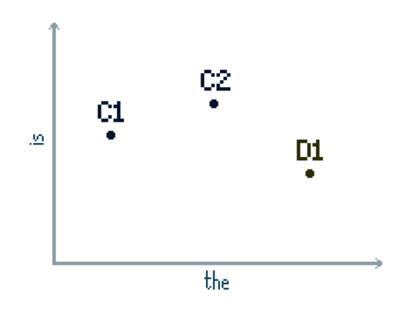

This is an artificial example, of course, but in real world there is high probability that in our simple case of three texts, points of Christie would appear closer to each other than to the point of Doyle. Remember, all our information here comes only from frequencies of *two* words. We also can add third dimension to add even more information about the points (let it be the word “of“).

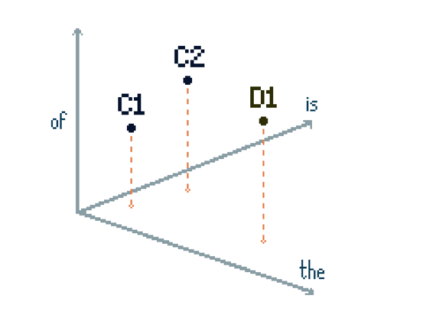

Now when you look at the drawing, texts are floating at some “distance“ from each other, the differences of which you can get at a glance. Our eyes here perceive the so-called “Euclidean“ distance, which is a straight line between two points on a plane - the shortest path. That is one way of determining a “difference“ between texts, we just did it, rather informally, thanks to texts being represented on a plane and the power of our vision.

Stylometry is a quest for determining textual differences which could be expressed through some quantifyable features. Word frequencies are just a tip of the iceberg, one of the most easily accessible layers. Over the years different sets of features were proposed to capture a stylistical variation: word length, sentence length, punctuation, character sequencies (n-grams), parts of speech, function words or mix of those. For poetry, which comes as a speech with more organization, these features could be extended to meters, rhythmical forms, types of rhyme, stanzas and their interactions with other levels of language (say, meter & morphology, rhythm & syntax).

The choice of the features would usually depend on the type of text in question and the specifics of the task. Stylometry originated around problems of authorial identity and is closely tied with questions of individual variations in text (a style, we can say, is an idiosyncratic way to write), thus it values features that would reveal a unique behaviour of an author, their “fingerprint“ value (authorship attribution & forensics are closely linked, see below). However, questions could be asked on the different scale - instead of in an author, for example, we could be interested in historical dynamics of literary language and forms it was using.

## A distributed style

Which features should represent a “style“, then? Which words to choose, that would matter? When to stop, if potentially there are so many features which vary significantly to distinguish between texts, between authors, between genres?

There was a Russian scholar B.I. Yarkho, who was a pioneer of quantiative turn in literary studies in 1920-1930s, long before this turn was even started to happen. He was extremely limited in calculation resources and did almost everything alone. In study on differences between Classical & Romantic drama he wrote, that we can accumulate as many features for analysis as we want, but in reality we can stop after finding features that will distinguish, that will establish a difference. This is an image of stylometry work in the reality of extreme limitations. The echo of it could be felt even now, in approach that is sometimes called “feature-construction“: we take an educated guess on what matters first, what makes a difference, and then apply this to a larger case or set of cases. Feature construction is not only time consuming, but sometimes could feel arbitrary: why we are so sure that words “the“, “of“, “is“ are more imporant at caputring textual variance than “while“, “ship“, “or“?

There was other literary scholar, who already was working with computers - a power spike in computational powers so large it is even hard to compare it with 1930s. His name was John Burrows (1923-2019) and he believed, that indivudual “style“ of an author should be found not in a handful of “strong“ features, but is distributed across wide range of “things“ in texts. Even small variations would accumulate to be imporant in the end, we just need to allow features to be expressed. In a now-classical 2002 paper, Burrows described a method which he called “Delta“. Delta can serve as a great introduction to authorship attribution problem and multivariate analysis of text in general.

# Burrow’s Delta: a walkthrough

Delta is essentially a method of determining a “distance“ between texts using combined expression of large number of features. Then delta-scores are used for ranking closest candidates for some text A to determine authorship.

Originally Burrows proposed to use from 50 to 100 words ordered by their frequency rank: i.e. most frequent words of the corpus in question. Previously we have seen what textual distances could look like for 2 or 3 features (in two or three dimensions). What about 50 or 100 dimensions? Our brains which are trained to process 3d world go a bit dizzy when we try to imagine 50 dimensions, but mathematically it is all the same, with just additional variables to calculate Euclidean “line“ or other distance. In this part we will go step by step through Burrow’s method from counting words to ranking texts.

## 1. Simplified example (wrong Delta)

In computational analysis of texts we always represent a text by some set of numbers. This is a neccessary reductive operation, because we “reduce“ a text to some quantifyable features and accound only for them.

Recall our artificial example with detectives: geometrically our texts are points floating in three dimensions (words) and they have coordinates. It means that we can express them purely algebraically as **vectors** - an ordered set of three elements (in mathematics it is also called a 3-tuple).  
Thus:

> Christie 1 (C1). C1 = (frequency of “the“ (C1), frequency of “is“ (C1), frequency of “of“ (C1))

> Christie 2 (C2). C2 = (frequency of “the“ (C2), frequency of “is“ (C2), frequency of “of“ (C1))

> Doyle 1 (D1). D1 = (frequency of “the“ (D1), frequency of “is““ (D1), frequency of “of“ (D1))

Here our texts would be represented by three values each and position of that value would correspond across texts (first number in our representation would always be the frequency of word “the“).

We will need some real numbers to proceed, so our words would be replaced by values. Let’s take artificial numbers just for the sake of calculation simplicity. First, let’s make a table with word frequencies in our three texts:

| word | C1 | C2 | D1 |
| --- | --- | --- | --- |
| the | 18 | 15 | 25 |
| is | 11 | 4 | 14 |
| of | 9 | 8 | 5 |

What you can notice here is that:

1. word counts differ accross them (yay, we captured some *variation*!);
2. these text are of unequal size;
3. each text is represented by three values which correspond to the same word across texts.

Now we can rewrite them as proper **vectors**:

$C_{1} = (18, 11, 9)$

Remember, these are **absolute** values for word counts. We will continue with them **only for demonstratitional purposes** for now, but later we will switch to **relative** numbers (the part this word takes from the overall text size).

The easiest way to determine a difference between two text now (say, C1 & C2) would be an **extraction**. This is the path that Burrows also took. When we extract a vector from another vector (of the same size), all corresponding elements are extracted independently. So:

$C_{1}-C_{2} = (-7, -3, 4)$

What we have now is **the vector of differences**. It holds differences of frequencies for each of the three words. Now, how to determine overall difference, arrive at one value that would stand for “distance” between two texts? Well,the most obvious way is to **sum up absolute differences** - as Burrows proposed in Delta method (we notate it with greek letter $\Delta$). We don’t care if the value is **positive or negative**, because we are only interested in the *magnitude* of difference, not in its *direction* (this is also the reason for $C_1-C_2 = C_2-C_1$, it doesn’t matter how you count a distance, from point A to B, or B to A; in normal conditions it should stay the same)

$|C_1 - C_2| = |(-7, -3, 4)| = (7, 3, 4)$

$\Delta(C_1, C_2) = \sum |C_1 - C_2| = 7 + 3 + 4 = 14$

14! This is our distance between artificial Christie 1 & Christie 2 expressed with a single value. The only other thing Burrows had in mind is a division by number of used features - in our case there are three of them (three words).

$\Delta(C1,C2) = \frac{(7 + 3 + 4)}{3} = \frac{14}{3} = 4.66..$

We can generalize this case of a distance calculation to a formula:

$$\Delta(x, y) = \frac{\sum |x_i - y_i|}{n}$$

It doesn’t really matter if we account for 3 words in $x$ and $y$ texts, or 3000: the calculation will remain the same and it will end up being a sum of word differences between two texts.

It should be obvious that $\Delta(C_1, C_1)$ - the distance from a text to itself is **zero**. You don’t need to go a long path from you to yourself (if we are not speaking of methaporical journeys of finding self - these could be endless) - it is literally the same point. So all things that are closer to zero, are “closer” to you. Usually texts of one author are these “closer” things, while texts of other authors exhibit different style that is, in the end, expressed in different set of distances.

To get to that point of “ranking” texts around C1 we need at least one other measurement, namely, a distance from C1 to D1. I’ll drop long calculations, but:

## 2. True Delta (z-transformation)

It is time to reiterate, that all calculations of Delta so far were actually **wrong** - because we relied on **absolute frequencies** instead of **relative**. Variation in size of text will influence absolute numbers dramatically and it would overshadow the real role of a word in a text. That is why usually **percentage** of word frequency relative to text size is used. Let’s return to our table.

| word | C1 | C2 | D1 |
| --- | --- | --- | --- |
| the | 18 | 15 | 25 |
| is | 11 | 4 | 14 |
| of | 9 | 8 | 5 |

C1, C2 and D1 are clearly of unequal size, so we calculate total (assume all these texts are made out of just three words!).

| word | C1 | C2 | D1 |
| --- | --- | --- | --- |
| the | 18 | 15 | 25 |
| is | 11 | 4 | 14 |
| of | 9 | 8 | 5 |
| SUM | 38 | 27 | 44 |

Using our knowledge of total size we calculate relative numbers: word “the” of text C1 occures 18 times out of 38. 18 / 38 = 0.47 (47%). The table now transforms to:

| word | C1 | C2 | D1 |
| --- | --- | --- | --- |
| the | 0.5 | 0.6 | 0.6 |
| is | 0.3 | 0.1 | 0.3 |
| of | 0.2 | 0.3 | 0.1 |

This is better, but not enough. Word frequencies in a text large enough follow Zip’s Law (or so-called “power-law distribution”): it means that only a handful of most frequent words are VERY FREQUENT - pronouns, articles, prepositions - while the overwhelming majority of words are very rare and their frequency decreases exponentially when we start to move away from words in top frequency ranks.

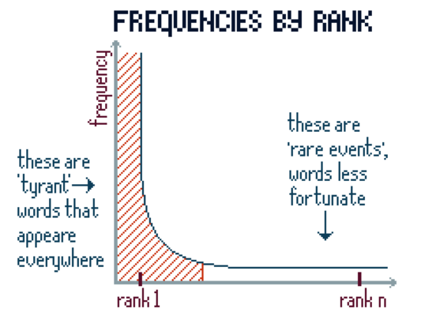

For our distance calculation method it means that most frequent words will dominate the space of differences, while less frequent words will add only a fraction of information to the final delta score. That is why Burrows was running Delta scores on **z-scaled** frequencies, or z-scores.

**Z-scaling** is also called a **standartization**, because we take very non-normal tyrannical distribution (words in Zip’s law) and transform it to something different - a measure of difference between usage of these words across texts in corpus. So we standartize values with respect to *how* they appear in our “population” of texts. The result of this operation is that, irrespectively of a their position in the frequency rank we give all features a space to express information. Picture below illustrates what happens when we try to measure fading differences in relative frequencies vs. measuring differences in z-scores. Red and blue colors represent two imaginary texts that are compared:

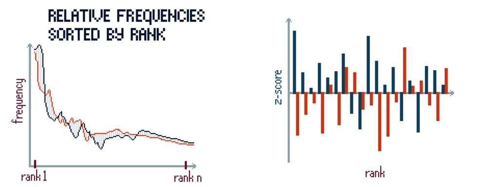

Z-scores express the amount of variation - how far a frequency of a word in text A deviates from the mean frequency of the word in all observed texts. This difference is expressed in the amount of “standard deviations” - the measure of variance in the data.

Let’s proceed with example: how far away is word “the” in Christie 1 from the mean frequency of “the” across three texts? We take the frequency of “the” in Christie 1 and extract from it an average frequency of “the” across our corpus. Which equals in our example to:

$0.47 - \frac {0.47 + 0.56 + 0.57} 3$ $0.47 - (1.6 / 3) = 0.47 - 0.53 = -0,0633$

The standard deviation of “the” frequencies is 0.055 (we ommit SD calculation here). Z-score of “the” in C1 would then be:

$$z(C_1"the") = -0.0633 / 0.055 = -1.15$$

General formula to calculate z-score is:

$$z(x_i) = \frac{x_i - \mu(x)}{\sigma(x)}$$
Where $\mu(x)$ stands for the arithmetic mean of a feature, and $\sigma(x)$ - for standard deviation of this feature across corpus.

| word | C1 | C2 | D1 |
| --- | --- | --- | --- |
| the | -1.1 | 0.4 | 0.7 |
| is | 0.4 | -1.1 | 0.7 |
| of | 0.2 | 0.9 | -1.1 |

We see how words deviate across our texts in the observed sample, some are quite close to the mean (“of“ in C1) some are quite far away in both directions (“the“ in C1 or “of“ in C2).

Proper Delta distance calculation thus is based on standartization and z-scores are essential to it’s success. Some even say that z-transformation is one of the most crucial operations in multivariate authorship attribution when using distance measurements (Evert et al.).

Nevertheless, all other operations remain the same and to get to the delta between C1 & C2 we need to perform steps that should be familiar. First, we calculate difference between vectors of texts C1 & C2:

$C1-C2 = (-1.15 - 0.45, 0.41 - -1.14, 0.23 - 0.87)$

$|C1-C2| = |(-1.6, 1.55, -0.64)| = (1.6, 1.55, 0.64)$

Then we sum together absolute values of differences and divide the result by the number of features (three):

$\Delta(C1,C2) = (1.6 + 1.55 + 0.64) / 3 = 1.26$

If we do this calculation pairwise for all possible pairs we can represent those values in a table, which is called a “matrix of distances“ (note that this matrix is symmetrical along diagonal, so $\Delta(x,y) = \Delta(y,x))$:

|  | C1 | C2 | D1 |
| --- | --- | --- | --- |
| C1 | 0.0 | 1.3 | 1.2 |
| C2 | 1.3 | 0.0 | 1.4 |
| D1 | 1.2 | 1.4 | 0.0 |

**!NB** It is crucial to understand that z-transformation makes the “differences” between texts **absolutely dependent on the context, i.e. texts which we include in observation**. If we would add another, fourth text to the mix:

1. It will change the **distribution** of values and
2. **mean frequencies** will change, which means
3. **z-scores** will be distributed differently, that will
4. lead to the shift in **pairwise differences** between texts, which
5. obviously will influence **final distance** number.

Let’s add Doyle 2 text, express it with the frequencies of the same three words: $D_2 = (43, 21, 6)$. When we measure Delta with z-transformation we get to a new distance matrix:

|  | C1 | C2 | D1 | D2 |
| --- | --- | --- | --- | --- |
| C1 | 0.0 | 1.3 | 1.1 | 1.3 |
| C2 | 1.3 | 0.0 | 1.4 | 1.7 |
| D1 | 1.1 | 1.4 | 0.0 | 0.4 |
| D2 | 1.3 | 1.7 | 0.4 | 0.0 |

The whole relationship map now is different, because the initial context changed - actually now there is **more** context to judge mutual positions of texts. Now D1 & D2 appear very close to each other (0.43), while C1 & C2 text seem distant from D and from each other. This reminds us, that approach to the “style“ here depends on “average“ and observed distribution of features. The idea that “style“ is deviation from some “average“ (neutral language) is actually old in linguistics. The problem is that it’s may be impossible to define “average“ in the world of natural language - however, we can find this central point in the world of numbers.

## Visualizing difference

When the fourth text was added to the matrix of distances, it became slightly harder to read the table. The complexity of between-textual relationships will grow exponentially when adding more texts to analysis. To represent and validate these relations additional analysis is usually implemented:

1. We can arrange texts on two-dimensional plane based on distance information while trying to express as much variation as possible (e.g., Multi-Dimensional Scaling)
2. We can find natural clusters in our distance table and organize them in a tree (two closest texts will be united in one cluster, then distances will be recalculated according to the new cluster, then next closest texts/clusters determined and so on). This technique is called hierarchical clustering and is essential for work with distance-based data.
3. We can represent closeness of texts as a network of relationships. One particular method, for example, assigns strength of ties based on three closest neighbours of a text (3 - for the closest, 2 - for the second closest, 1 - for the third closet), disregarding all other connections. Nework builds on this data, which allows to represent complex datasets (hundreds of text) with relative accuracy.

# Distances

## How far is it to author X if we are in Manhattan?

We were speaking a lot about intuitive distances in the beginning and then switched to Burrow’s Delta. We called it “distance“ too, but dealt with it only algebraically. To understand what Delta is doing geometrically, we need to imagine Manhattan.

If you are standing in Manhattan and you are an ordinary human, you’ll have limited options for moving from point A to point B

Certainly, you cannot just take the shortest path - a straight line - and move in a proper ergonomic euclidean way. You’ll have to follow a grid - move along avenues and take turns at streets. If you do that, how you would calculate the distance you have covered?

Well, you’ll need to simply *sum together* the distance you covered via the avenue and the distance you covered via the street. Let’s say, the avenue is the dimension of a word “the“ and the street represents the dimension of “is“. Texts A & B are obviously located in different places in these two dimensions - to know their distance in Manhattan fashion is to **sum together their differences in street/avenue (“the“, “is“) positions**.

We are, of course, rarely taking a walk between texts with a step tracking app. First and foremost it is the “coordinates“ of texts that we are dealing with - and these coordinates are aligned in the same vector space of features (along same “avenues“ and “streets“).

We need to know “city-block walking distance“, but we have only coordinates of $A = (street_A, avenue_A)$ and $B = (street_B, avenue_B)$. The question “how far to go“ could be answered by summing together the difference in “street“ position $(street_A - street_B)$ AND difference in “avenue“ position $(avenue_A - avenue_B)$. These differences on a plane also make up two “legs“ of right-angled triangle: a path that a person would cover (see further, but: by knowing two legs of a triangle we can easily calculate “how the bird flies“-Euclidean distance, or the hypothenuse: $Euclidean(A,B)=\sqrt{(street_A - street_B)^2 + (avenue_A -avenue_B)^2}$)

What Burrows was doing with his Delta intuitively - mathematicians knew for a long time and called it “Manhattan“ or “city block“ distance. “Manhattan distance“ is a way to navigate multidimensional world like it is made **only of avenues and streets**. And what could be done with two dimensions - mathematically could be done with any number of them (say 100 most frequent words would represent 100-dimensional space, but please don’t try to imagine 100th dimensional “avenue“).

There are many ways to measure distance between “points“ in multidimensional world - dozens of different metrics were implemented , for different data types, probabilities, bits, normal and skewed distributions, and so on. We mentioned Euclidean distance - in Manhatann birds usually don’t care about a grid and will fly a straight line from A to B. To know Euclidean distance is to know Pithagorean teorem and calculate the length of the AB line as hypothenuse of a right triangle.

One of the best performing distance measurements is “cosine distance“, which is derived from cosine similiarity. In geometrical terms a cosine distance could be understood as a “point-of-view“ distance. Imagine you’re looking at the Manhattan panorama while standing on a ship’s board. Some skyscrapers would be visible and appear close together, even if in “euclidean“ terms they might be far away from each other, while skyscrapers in some other part of the landscape would be visually in completely different area. This difference could be measured as difference in cosine of the angels between projected “view vectors“. The cosine similarity measures not the “magnitute“ of difference (as euclidian bird does), but spacial “alignment“ of things in the landscape. Because our “textual landscapes“ are usually very complex multidimensional representations, this approach of point-of-view alignment could represent difference in a more nuance.

Many modern variations of distance measurements for authorship attribution utilize cosine similarity with z-transformed feature frequencies. It appears to be current state-of-the-art in non-supervised approaches of catching authorial signal in a given set of texts.

# Authorial identity, fingerprints, ear shapes and detective work

Several times in this text I have used words “authorship“, “authorial signal“, “authorial style“ and so on. An author is definetely a complex concept, partly constructed by the symbolic economy of a cultural field, a “branded“ commodity, partly - being famously “dead“, irrelevant for a text they wrote. Roland Barthes used his blasphemous idea to illustrate a conceptual shift from the perspective of an author, as a tyrannical creative force, to the reader who freely transforms and reassembles textual meanings.

The long practice of stylometry and forensic authorhsip attribution tells us that “author“ definetely exists, however this “existence“ - a unique, idiosyncratic ways in which texts of one author are made - may belong to a very different level compared to how “authors“ are usually represented in literature classes.

To unpack this statement we need go back to late 19th century - a positivistic age, which introduced a lot of breaktroughs in the identification, systematized police work and made clue-seeking detectives to become new heroes of European fiction - a power-fantasy figures of ultimate epistemic techniques, who possed ability to reveale true identity of events and people through interpretation, induction and deduction.

## Knowing an artist from the shape of ears

Major scandal struck European art-world when mysterious Russian - Ivan Lermollieff - published series of articles in 1874-1876 *Zeitschrift für bildende Kunst* which introduced a new method of attribution of paintings. His idea was simple - authorship is revealed through small secondary details of the painting, that are very frequent yet usually invisible for an art expert, who engages with high levels of painting - like ideas, composition, figures, lightning techniques, etc.

Lermollieff (a pseudonym of an Italian art critic Giovanni Morelli) proposed to look at the painings not for ideas and brilliance of, say, Rembrandt, but for the forms of ears, nails and fingers - these kinds of things. He thought that these small details are usually very hard to notice and imitate, they are the shorthands for painter’s brush, and thus are less influenced by a particular school or workshop affiliation. At the same time very distinctive features like composition, colors, painting style, figures and postures are very easy to notice and to learn - and, thus, to copy and reproduce. Lermolieff proposed many re-attributions that would change established authorship dramatically.

Of course it raised a storm. Primarily because the world of art was mixing together the individual “identity“ with percieved cultural “value“ of an artist. For sure we can’t say if this is a work of a genius painter by looking at the ear shapes in their paintings? Genius should be located somewhere else, right?

Outside of the art history the case of Giovanni Morelli is well known because of Carlo Ginzburg’s essay “Clues: Roots of an Evidential Paradigm“, where the method of attribution is shown to follow a general epistemological model of 19th century forensics, that is behind both Scherlock Holmes deduction and Zigmund Freud’s psychoanalysis. We can add here: and behind stylometry too.

## Finding textual fingerprints

Dactyloscopy was introduced and spread rapidly across Western law-enforcing institutions around the same time. Fingerprint is probably the closest example of pure “identity“, separated from all social,cultural and personal dimensions of a person. If we would look for a very long time at a fingerprint - even assemble a whole institution of smart people to look at it - we would still won’t be able to tell what the person behind this fingerprint likes to eat for breakfast, what are their political views and which colors they prefer. The “genius“ or the Spirit does not live in a fingerprint (Hegel would probably hate this statement).

Quest for identity in stylometry and authorship attribution in general, is similar to “identification“ problem in law-enforcement. The reason why dactyloscopy spread so quickly is because fingerprints proven to be cheaply accesssible **feature with limitless variability** across people population. Person would usually match to it’s fingerprints on unique one-to-one basis. Person won’t have any contol of expressing their identity through fingerprints (it’s something nature makes) and no way of altering it (except for, maybe, destroying it, but it is generally painful and marks you even better - there are not so many people with **missing fingerprints**).

Early stylometry methods and thinking followed the line of “identification“: that is the reason why today it still bears old metaphors of detective work and is represented in forensic practices. Quest for extracting authorial identity through text revolved around features that would be: 1) wide-spread, 2) variable, 3) invisible to (unconciously used by) the author. Early stylometric attempts involved counting masculine to feminine rhyme ratio in Shakespeare dramas, most frequent function words for establishing chronology in Plato’s works, and, somewhat famously - variation in usage of words of different lengths.

## Characteristic curves & authorial spectroscopy

The last example reveals positivistic roots of stylometry very clearly. American physicist Thomas Corvin Mendenhall published an article called “Characterstic curves of composition“ (1887). He suggested a method for verification and attribution of authorship based soley on usage of words of different lengths. The idea of textual “curves“ came directly from 19th c. spectroscopy: dispercing visible light to spectrum to identify materials that make up its source (say stars, or comets). Authors were gloriously compared to the elements of materia, in Mendenhall’s own words:

> If, now, it shall be found that with every author, as with every element this spectrum persists in its form and appearence, the value of the method will be at once conceded […] Wherever and whenever [hydrogen’s spectrum] appears, it means hydrogen.

Information on word length is 1) abundant in any text large enough, 2) probably varies across authors because it is 3) not under concious control. Sophisticated writers may pay attention to - and to some extent control - different, complex and nuanced aspects of natural language, but you wouldn’t think a word length is something they are constantly worried about.

The method was very simplistic for contemporary taste, but very amusing by the standards of the late 19th century linguistics. Mendenhall counted how many words of which length appear across texts of an author - how many 1-character words (“a“, “I“) were used in a text, how many 2-character words, 3-character and so on… The work so painstaking and boring in the end of 19c., it is beyond my imagination today. However, it allowed Mendenhall to derive “curves of composition“ from given texts, or, simply - a distribution of words lengths.

When Mendenhall later applied this method for identification of an author, he immediately found variance in those. Curve of Shakespeare’s plays looked differently from the curve of Francis Backon. However, in a most striking Victorian way, curve of Shakespeare was indistinguishable from the curve of Marlowe! This just can’t happen randomly, right?

The word lengths became the “ears“ and “fingers“ of authorship attribution in texts. Other highly influential features proposed in 20th century that capture identity included: sentence-length, different sentence to paragraph ratios, word length in syllables (actually producing good performance for metrical poetry ), super frequent “function“ words, distribution of word boundaries in a verse lines. For a long time stylometry was about catching pure authorial identity - not the “essence“, the “meaning“ or the “substance“ of literary work or author. Only the difference that could be expressed in a quantifyable way. Imagine getting a Shakespeare on the lit exam and starting to characterize his works with something like “two-character words were surprisingly rare in *Hamlet* when compared to chronicles“

## Detective’s work

Large multidimensional vectors of features, that are widely used in stylometry today, however, do introduce a blurness in a distinction between “identity“ and “substance“. Especially words. Words - even counted as independent frequencies - redundantly convey **lots** of information. Words may signal genre, they may signal authorial gender, they may signal chronological change - because language use changes over time and may naturally introduce differences between authors of different periods (or even between texts of the same author). The same “chronological contamination“ can be true for other features - e.g. derived from syntax and morphology.

This means that the metaphor of a “fingerprint“ in authorship attribution is rather misleading. Here we have a “fingerprint“ of a person with some personal “substance“ mixed in: some bits about hobbies, about age, about family and education. For computational text analysis these are not exactly bad news, because we can construct our corpus and features around problems other than authorship attribution (say genre or chronology). But the “attribution“ task remains closely linked to positivistic identification, to the age of detectives and *depends* on controlling for signals that are not pure “style“, that do not signal pure difference in identity. The discourse of textual identification, surprisingly remained almost unchanged from late 19th century to the present days:

> **Mendenhall, 1887:** [Our method] offers a means of investigating and displaying the mere mechanism of composition […] it might reveal **characteristics which a writer would make no attempt to conceal, being himself unaware of their existence**

> **Morozov, 1916:** Couldn’t we use frequencies of these [function words] **to recognize authors - as we recognize them by looking at their portraits?** […] [Those] curves seem similar to the spectrums of chemical elements […]

> **Burrows 2002** Wealth of variables, many of which may be weak discriminators, almost always offer more tenable results than a smaler number of strong ones. **Strong features, perhaps, are easily recognized and modified by an author and just as easily adopted by disciples and imitators.** At all events, a distinctive “stylistic signature“ is usually made up of many tiny strokes.

> **Cafiero & Camps 2019**: In contrast, looking at the distribution of more authorial features […] reveals distributions that are closer to normality […] **The less thematic nature of these features makes them harder to perceive, to identify intuitively, or to interpret in other than authorial term**

# Closing words: identity leak

Quotes above reveal a latent, but continuous arms race between a stylometrist and an invisible, implied falsifier, imitator or author themselves. The more incomprehensible and uncontrollable the distinctive feature of a text is - the better. It means that authors couldn’t conceal their textual “fingerprint“ - because they are not really aware of what this fingerprint might be - and imitators couldn’t reliably copy these identities (ending up copying something else).

This arms race, however, is incredibly one-sided, existing mainly in the heads of scientists and forensic experts. Abundance of effective methods for extracting authorial signal from text is proportional to the lack of defense tools against it (it’s not like there aren’t any: but they are on the loosing side of the battle).

The problem is - and stylometry, focusing on invisible features of authorship, teaches us it - we all are authors. Distinctive textual identity is something that is distributed equally across the population, unlike fame, accumulated symbolic capital, position in literary canon and other lucky chances. It doesn’t matter how unknown we are or how well we control narratives and writing tricks - we are identifiable through texts.

I leak my identity while I’m writing this. We leave our traces in messengers, chatrooms, forum posts, school essays and dissertations. Even if we write in constructed languages - like Clingon or Elven Quenya - our cognitive habits shape the texts in a unique way. Honestly, we are sitting ducks for stylometry - especially when it may be deployed by a state surveillance, in a situation of extreme power assymetry. Hong Kong protests of 2019 clearly showed us how civic machine learning technologies are integrated in a surveillance networks and how extremely successful they are at establishing identity. If it’s not the facial recognition - it is your posture and walking habits that give you away. It’s really everything - the way you dance, the way you walk, the way you look, the way you write (the way you use Internet, hello “digital fingerprint“).

I sincerely hope that the worst application of identity recognition through dance would be automatic fines for a really bad dancing in a club. And I hope that the state-of-the-art textual stylometry will only solve obscure questions of authorship in Early Modern drama. However, the latter is unlikely: stylometry can be (and is) invasive in private matters - this is largely a sub product of it’s methodological aims and rigorous exploration of variance in style.

These closing words aim at identifying the identity: if we will know where to look, there won’t be anything “invisible“ and “uncontrollable“ about ourselves. In a similar way that we build machines for identifying the style, we can build machines for altering the style and confusing the positivistic “spectroscopic“ assumptions about hydrogen always being hydrogen. By the way, Deep Learning solutions for sequential data with stylistic transpositions may be one way to fight. Just saying.

*Created by Artjoms Šeļa, illustrations by Tonya Martynenko.*

[figure not shown]